# Advanced DataVisualization with ggplot

## Advanced DataVisualization with ggplot - Coordinates and Facets

this talks about the coord_ function family.

We can :

- zoom in

Set basic zoom limits to the coordinate system we want to display

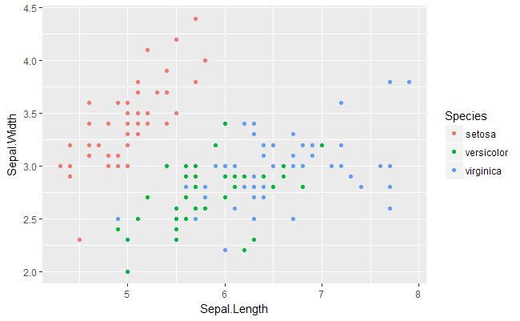

```r
# ggplot sets automatic limits to the dataset, according to the data available
ggplot(iris, aes(Sepal.Length, Sepal.Width, col = Species)) +
  geom_point()
```

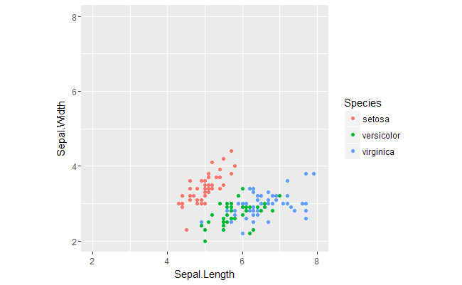

```r
# We can set the data to use uniform coordinates instead
ggplot(iris, aes(Sepal.Length, Sepal.Width, col = Species)) +
  geom_point() +
  coord_equal(ylim = c(2, 8), xlim = c(2,8))
```

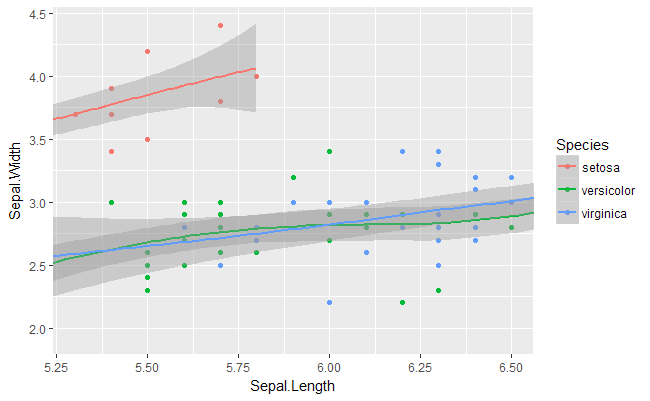

```r
# First: Set limits without cutting of values
ggplot(iris, aes(Sepal.Length, Sepal.Width, col = Species)) +
  geom_point() +
  geom_smooth(method = "loess", se = T, span = 0.9)  +
  coord_cartesian(xlim = c(5.3,6.5))
```

```r
#
```

## Creating Pie Charts - Using the Polar coordinate system

We can transform data to a polar, circular represenation using the `coord_polar()` system.

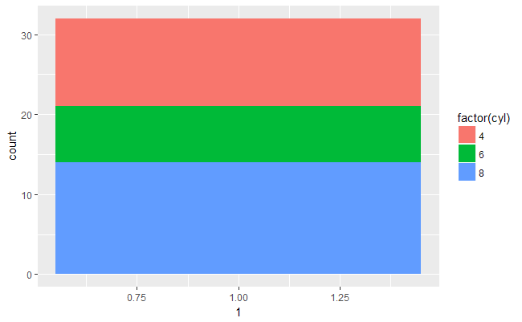

```r
# This creates a dummy variable to fill the proportion of the cyl factors
thin.bar <- ggplot(mtcars, aes(1, fill = factor(cyl))) +
  geom_bar()
# We turn this
thin.bar
```

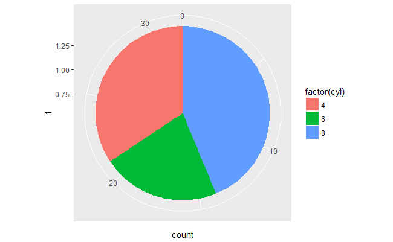

```r
# Into a pie chart, by plotting it along a polar coordinate system and specify `theta` to be "y"
thin.bar + coord_polar(theta= "y")
```

## Facet Layers

They are a usefull layer to produce small multiples, a concept popularized by Edward Tufte in his 1983 Book “Visualization of Quantitative Information”.

The basic idea is, to keep the limits of a plot identical and spread the data over a multitude of parallel plots, broken down according to a factor level.

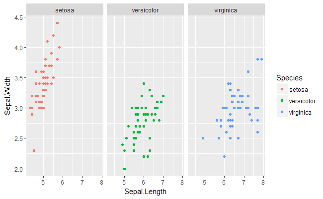

```r
ggplot(iris, aes(Sepal.Length, Sepal.Width, col = Species)) +
  geom_point() +
  facet_grid(. ~ Species)
```

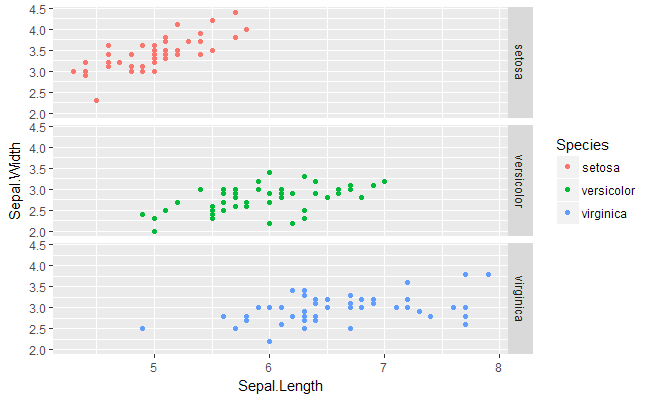

```r
# We can split based on columns, as above, or along the rows
ggplot(iris, aes(Sepal.Length, Sepal.Width, col = Species)) +
  geom_point() +
  facet_grid(Species ~ .)
```

And this can be split both on columns and variables, specifying two categorial variables to compare.

```r
str(mtcars)
```

```
'data.frame':   32 obs. of  13 variables:
 $ mpg   : num  21 21 22.8 21.4 18.7 18.1 14.3 24.4 22.8 19.2 ...
 $ cyl   : Factor w/ 3 levels "4","6","8": 2 2 1 2 3 2 3 1 1 2 ...
 $ disp  : num  160 160 108 258 360 ...
 $ hp    : num  110 110 93 110 175 105 245 62 95 123 ...
 $ drat  : num  3.9 3.9 3.85 3.08 3.15 2.76 3.21 3.69 3.92 3.92 ...
 $ wt    : num  2.62 2.88 2.32 3.21 3.44 ...
 $ qsec  : num  16.5 17 18.6 19.4 17 ...
 $ vs    : num  0 0 1 1 0 1 0 1 1 1 ...
 $ am    : Factor w/ 2 levels "0","1": 2 2 2 1 1 1 1 1 1 1 ...
 $ gear  : num  4 4 4 3 3 3 3 4 4 4 ...
 $ carb  : num  4 4 1 1 2 1 4 2 2 4 ...
 $ cyl_am: chr  "6_1" "6_1" "4_1" "6_0" ...
 $ group : num  0 0 0 0 0 0 0 0 0 0 ...
```

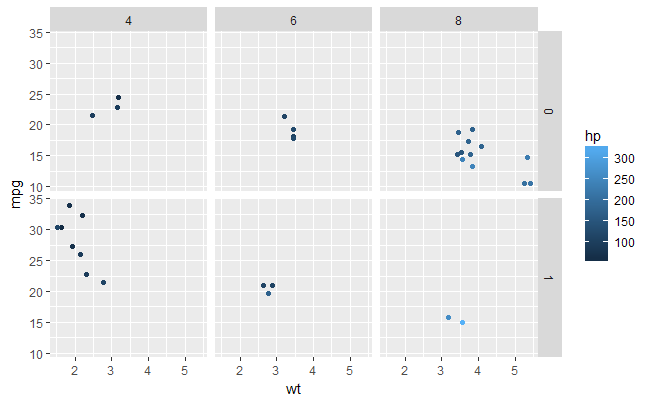

```r
ggplot(mtcars, aes(wt, mpg, col = hp)) +
  geom_point() +
  facet_grid(am ~ cyl)
```

### Plotting multiple variables at once

This exercise shows how to plot too many variables at once, using facets, aestethic matches

Its just plain ugly!!!

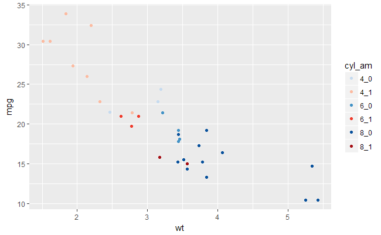

```r
# Import the brewer palet package
if(!require(RColorBrewer)){install.packages("RColorBrewer"); library(RColorBrewer)}
# Code to create the cyl_am col and myCol vector
mtcars$cyl_am <- paste(mtcars$cyl, mtcars$am, sep = "_")
myCol <- rbind(brewer.pal(9, "Blues")[c(3,6,8)],
               brewer.pal(9, "Reds")[c(3,6,8)])
# Basic scatter plot, add color scale:
ggplot(mtcars, aes(x = wt, y = mpg, col = cyl_am)) +
  geom_point() +
  scale_color_manual(values = myCol)
```

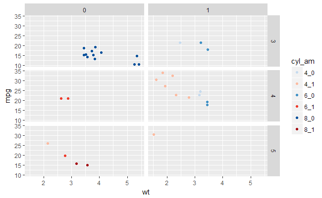

```r
# Facet according on rows and columns.
ggplot(mtcars, aes(wt, mpg, col = cyl_am)) +
  geom_point() +
  scale_color_manual(values = myCol) +
  facet_grid(gear ~ vs)
```

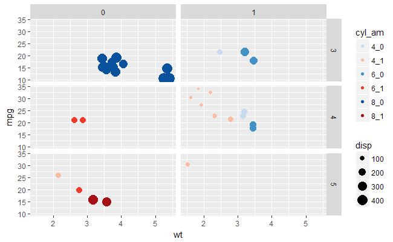

```r
# Add more variables
ggplot(mtcars, aes(wt, mpg, col = cyl_am, size = disp)) +
  geom_point() +
  scale_color_manual(values = myCol) +
  facet_grid(gear ~ vs)
```

## Freeing rows or columsn which are not present in subplots made by facetting

When we facet on a variable that does represent only a single category, we end up with lots of duplicates. We can remove them, as we would with `rm.na`, by specifying the axis to free in the function call to `facet_grid()`